# Cleanup data, detect suspicious cases

2019-06-12

# 1 Setup

```r
library(tidyverse)
library(sjmisc)
library(here)
```

Where am I?

```r
here::here()
```

```
## [1] "/Users/sebastiansaueruser/Documents/research/Achtsamkeit_Studien/Necker/necker-cube-replication-saueretal2012"
```

## 1.1 Load data

```r
d_long <- readRDS(file = paste0(here::here(), "/objects/rawdata_long.Rdata"))
d <- readRDS(file = paste0(here::here(), "/objects/raw_data_person_level_rt_summary.Rdata"))

d
```

```
## # A tibble: 143 x 64
##       id STARTED             rt_md_hold rt_mean_hold rt_iqr_hold rt_sd_hold
##    <dbl> <dttm>                   <dbl>        <dbl>       <dbl>      <dbl>
##  1     1 2018-12-22 12:46:41      8835        10047.       8888       8888
##  2     2 2018-12-22 13:05:44      5690.        6756.       5293.      5293.
##  3     3 2018-12-22 13:16:03      7787         7187.       4286.      4286.
##  4     4 2018-12-22 13:23:32      5247         5106.       2955       2955
##  5     5 2018-12-22 13:25:33      1792         1792           0          0
##  6     6 2018-12-22 13:25:56      3119         3968.       3247       3247
##  7     7 2018-12-22 13:26:27      3694.        5753.       6334.      6334.
##  8     8 2018-12-22 13:29:01      4342.        6872.       8506.      8506.
##  9     9 2018-12-22 13:40:01      2581         3119.       2229       2229
## 10    10 2018-12-22 13:46:24      2814         3765.       2754       2754
## # … with 133 more rows, and 58 more variables: rt_md_flip <dbl>,
## #   rt_mean_flip <dbl>, rt_iqr_flip <dbl>, rt_sd_flip <dbl>,
## #   mindfulness_score <dbl>, mindfulness_training <dbl>, CASE <dbl>,
## #   SERIAL <lgl>, REF <lgl>, QUESTNNR <chr>, MODE <chr>, PE01_01 <dbl>,
## #   PE02 <dbl>, PE03 <dbl>, PE04 <dbl>, PE05 <dbl>, PE06 <dbl>,
## #   PE07_01 <chr>, PE08 <dbl>, PE08_06 <chr>, PE09 <dbl>, MA01_01 <dbl>,
## #   MA01_02 <dbl>, MA01_03 <dbl>, MA01_04 <dbl>, MA01_05 <dbl>,
## #   MA01_07 <dbl>, MA01_08 <dbl>, MA01_09 <dbl>, MA01_10 <dbl>,
## #   MA01_12 <dbl>, MA01_13 <dbl>, MA01_14 <dbl>, MA01_15 <dbl>,
## #   MA01_16 <dbl>, MA01_17 <dbl>, NW03_01 <chr>, NW04_01 <chr>,
## #   TIME001 <dbl>, TIME002 <dbl>, TIME003 <dbl>, TIME004 <dbl>,
## #   TIME005 <dbl>, TIME006 <dbl>, TIME007 <dbl>, TIME008 <dbl>,
## #   TIME_SUM <dbl>, MAILSENT <lgl>, LASTDATA <dttm>, FINISHED <dbl>,
## #   Q_VIEWER <dbl>, LASTPAGE <dbl>, MAXPAGE <dbl>, MISSING <dbl>,
## #   MISSREL <dbl>, TIME_RSI <dbl>, DEG_TIME <dbl>,
## #   mindlessness_score <dbl>
```

```r
d_long
```

```
## # A tibble: 20,139 x 66
##       id STARTED                rt rt_md_hold rt_mean_hold rt_iqr_hold
##    <dbl> <dttm>              <dbl>      <dbl>        <dbl>       <dbl>
##  1     1 2018-12-22 12:46:41  7050       8835       10047.        8888
##  2     1 2018-12-22 12:46:41  4857       8835       10047.        8888
##  3     1 2018-12-22 12:46:41   776       8835       10047.        8888
##  4     1 2018-12-22 12:46:41  1185       8835       10047.        8888
##  5     1 2018-12-22 12:46:41   231       8835       10047.        8888
##  6     1 2018-12-22 12:46:41   221       8835       10047.        8888
##  7     1 2018-12-22 12:46:41   180       8835       10047.        8888
##  8     1 2018-12-22 12:46:41   203       8835       10047.        8888
##  9     1 2018-12-22 12:46:41   387       8835       10047.        8888
## 10     1 2018-12-22 12:46:41   195       8835       10047.        8888
## # … with 20,129 more rows, and 60 more variables: rt_sd_hold <dbl>,
## #   rt_md_flip <dbl>, rt_mean_flip <dbl>, rt_iqr_flip <dbl>,
## #   rt_sd_flip <dbl>, mindfulness_score <dbl>, mindfulness_training <dbl>,
## #   CASE <dbl>, SERIAL <lgl>, REF <lgl>, QUESTNNR <chr>, MODE <chr>,
## #   PE01_01 <dbl>, PE02 <dbl>, PE03 <dbl>, PE04 <dbl>, PE05 <dbl>,
## #   PE06 <dbl>, PE07_01 <chr>, PE08 <dbl>, PE08_06 <chr>, PE09 <dbl>,
## #   MA01_01 <dbl>, MA01_02 <dbl>, MA01_03 <dbl>, MA01_04 <dbl>,
## #   MA01_05 <dbl>, MA01_07 <dbl>, MA01_08 <dbl>, MA01_09 <dbl>,
## #   MA01_10 <dbl>, MA01_12 <dbl>, MA01_13 <dbl>, MA01_14 <dbl>,
## #   MA01_15 <dbl>, MA01_16 <dbl>, MA01_17 <dbl>, NW03_01 <chr>,
## #   NW04_01 <chr>, TIME001 <dbl>, TIME002 <dbl>, TIME003 <dbl>,
## #   TIME004 <dbl>, TIME005 <dbl>, TIME006 <dbl>, TIME007 <dbl>,
## #   TIME008 <dbl>, TIME_SUM <dbl>, MAILSENT <lgl>, LASTDATA <dttm>,
## #   FINISHED <dbl>, Q_VIEWER <dbl>, LASTPAGE <dbl>, MAXPAGE <dbl>,
## #   MISSING <dbl>, MISSREL <dbl>, TIME_RSI <dbl>, DEG_TIME <dbl>,
## #   type <chr>, mindlessness_score <dbl>
```

# 2 Test for suspicious persons (level 2)

We use the level 2 data frame here.

## 2.1 Did not finish?

```r
d %>%
  count(FINISHED)
```

```
## # A tibble: 1 x 2
##   FINISHED     n
##      <dbl> <int>
## 1        1   143
```

All finished the study. Good.

## 2.2 (Nearly) no variance in the responses

.. for mindfulness_score

Compute sd of mindfulness score (on person level)

```r
mindfulness_score_sd <- d %>%
  ungroup() %>%
  select(contains("MA01"), id) %>%
  gather(key = item, value = value, -id) %>%
  group_by(id) %>%
  summarise(mindfulness_sd = sd(value, na.rm = TRUE))

mindfulness_score_sd
```

```
## # A tibble: 143 x 2
##       id mindfulness_sd
##    <dbl>          <dbl>
##  1     1          1.05
##  2     2          1.06
##  3     3          0.915
##  4     4          1.03
##  5     5          1
##  6     6          1.36
##  7     7          0.976
##  8     8          0.961
##  9     9          1.07
## 10    10          0.828
## # … with 133 more rows
```

Add this variable to main l2 data frame:

```r
d2 <- d %>%
  full_join(mindfulness_score_sd) %>%
  select(id, contains("rt_"), contains("mindful"), everything())
d2
```

```
## # A tibble: 143 x 65
##       id rt_md_hold rt_mean_hold rt_iqr_hold rt_sd_hold rt_md_flip
##    <dbl>      <dbl>        <dbl>       <dbl>      <dbl>      <dbl>
##  1     1      8835        10047.       8888       8888        286
##  2     2      5690.        6756.       5293.      5293.      1041
##  3     3      7787         7187.       4286.      4286.      1379
##  4     4      5247         5106.       2955       2955       1090.
##  5     5      1792         1792           0          0       5130
##  6     6      3119         3968.       3247       3247       1287
##  7     7      3694.        5753.       6334.      6334.      1635
##  8     8      4342.        6872.       8506.      8506.      4518.
##  9     9      2581         3119.       2229       2229       1382
## 10    10      2814         3765.       2754       2754       1280.
## # … with 133 more rows, and 59 more variables: rt_mean_flip <dbl>,
## #   rt_iqr_flip <dbl>, rt_sd_flip <dbl>, mindfulness_score <dbl>,
## #   mindfulness_training <dbl>, mindfulness_sd <dbl>, STARTED <dttm>,
## #   CASE <dbl>, SERIAL <lgl>, REF <lgl>, QUESTNNR <chr>, MODE <chr>,
## #   PE01_01 <dbl>, PE02 <dbl>, PE03 <dbl>, PE04 <dbl>, PE05 <dbl>,
## #   PE06 <dbl>, PE07_01 <chr>, PE08 <dbl>, PE08_06 <chr>, PE09 <dbl>,
## #   MA01_01 <dbl>, MA01_02 <dbl>, MA01_03 <dbl>, MA01_04 <dbl>,
## #   MA01_05 <dbl>, MA01_07 <dbl>, MA01_08 <dbl>, MA01_09 <dbl>,
## #   MA01_10 <dbl>, MA01_12 <dbl>, MA01_13 <dbl>, MA01_14 <dbl>,
## #   MA01_15 <dbl>, MA01_16 <dbl>, MA01_17 <dbl>, NW03_01 <chr>,
## #   NW04_01 <chr>, TIME001 <dbl>, TIME002 <dbl>, TIME003 <dbl>,
## #   TIME004 <dbl>, TIME005 <dbl>, TIME006 <dbl>, TIME007 <dbl>,
## #   TIME008 <dbl>, TIME_SUM <dbl>, MAILSENT <lgl>, LASTDATA <dttm>,
## #   FINISHED <dbl>, Q_VIEWER <dbl>, LASTPAGE <dbl>, MAXPAGE <dbl>,
## #   MISSING <dbl>, MISSREL <dbl>, TIME_RSI <dbl>, DEG_TIME <dbl>,
## #   mindlessness_score <dbl>
```

Check distribution of mindfulness score sd:

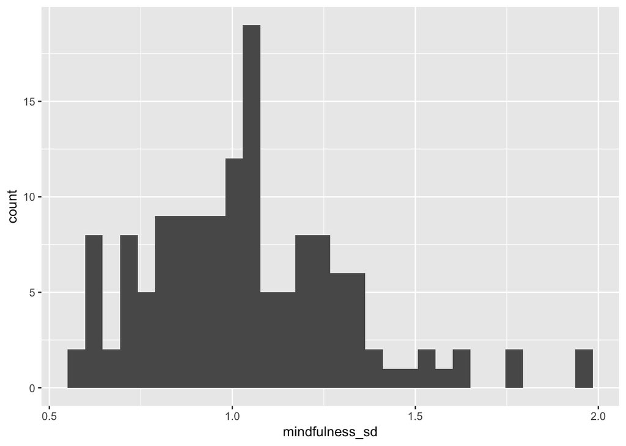

```r
d2 %>%
  ggplot(aes(x = mindfulness_sd)) +
  geom_histogram()
```

There is none with ZERO variance. Good.

Check cases with small variance:

```r
d2 %>%
  filter(mindfulness_sd < .8) %>%  # arbitrary value
  select(contains("MA01"))
```

```
## # A tibble: 27 x 15
##    MA01_01 MA01_02 MA01_03 MA01_04 MA01_05 MA01_07 MA01_08 MA01_09 MA01_10
##      <dbl>   <dbl>   <dbl>   <dbl>   <dbl>   <dbl>   <dbl>   <dbl>   <dbl>
##  1       4       4       4       4       3       5       5       5       4
##  2       3       1       1       1       1       3       2       2       1
##  3       1       1       2       3       2       2       2       2       2
##  4       3       3       2       4       4       4       3       3       3
##  5       4       2       3       4       3       2       3       3       3
##  6       2       3       3       3       4       4       3       4       3
##  7       4       4       5       4       5       6       5       5       5
##  8       3       3       4       3       5       5       5       4       4
##  9       3       2       2       3       4       3       4       4       3
## 10       5       4       4       6       5       5       6       5       5
## # … with 17 more rows, and 6 more variables: MA01_12 <dbl>, MA01_13 <dbl>,
## #   MA01_14 <dbl>, MA01_15 <dbl>, MA01_16 <dbl>, MA01_17 <dbl>
```

Looks ok.

# 3 Test for suspicous RT (level 1)

Now we work with the long (l1) data frame (`d_long`)

## 3.1 Check for too quick to be true (< 300ms)

Let’s say a flip below 300 ms is suspicious, ie., indicative of low data quality. Let’s look for those rt values.

```r
d_long %>%
  select(id, type, mindfulness_training, rt) %>%
  filter(rt < 300)
```

```
## # A tibble: 134 x 4
##       id type  mindfulness_training    rt
##    <dbl> <chr>                <dbl> <dbl>
##  1     1 flip                     0   231
##  2     1 flip                     0   221
##  3     1 flip                     0   180
##  4     1 flip                     0   203
##  5     1 flip                     0   195
##  6     1 flip                     0   261
##  7     1 flip                     0   213
##  8     1 flip                     0   212
##  9     1 flip                     0   209
## 10     1 flip                     0   217
## # … with 124 more rows
```

Which persons (`id`s) are involved?

```r
d_long %>%
  select(id, type, mindfulness_training, rt) %>%
  filter(rt < 300) %>%
  pull(id) %>%
  unique()
```

```
##  [1]   1   4  15  20  23  26  33  35  37  39  57  60  62  64  71  73  85
## [18]  92  93  94  96  99 114 119 130 135 140 143
```

## 3.2 Check whether first (few) trials of each block should be disregared

Maybe the (few) first trials on each block should not be counted, as folks need to get into the exercise in the first place. So let’s check whether the problems occur at the beginning of the blocks.

For that, we need an ID for each rt, ie., we need to indicate whether it was the first, second … trial of this person in this block.

```r
d_long2 <- d_long %>%
  group_by(id, type) %>%
  mutate(id_trial = row_number()) %>%
  select(id, type, id_trial, everything()) %>%
  ungroup()

d_long2
```

```
## # A tibble: 20,139 x 67
##       id type  id_trial STARTED                rt rt_md_hold rt_mean_hold
##    <dbl> <chr>    <int> <dttm>              <dbl>      <dbl>        <dbl>
##  1     1 flip         1 2018-12-22 12:46:41  7050       8835       10047.
##  2     1 flip         2 2018-12-22 12:46:41  4857       8835       10047.
##  3     1 flip         3 2018-12-22 12:46:41   776       8835       10047.
##  4     1 flip         4 2018-12-22 12:46:41  1185       8835       10047.
##  5     1 flip         5 2018-12-22 12:46:41   231       8835       10047.
##  6     1 flip         6 2018-12-22 12:46:41   221       8835       10047.
##  7     1 flip         7 2018-12-22 12:46:41   180       8835       10047.
##  8     1 flip         8 2018-12-22 12:46:41   203       8835       10047.
##  9     1 flip         9 2018-12-22 12:46:41   387       8835       10047.
## 10     1 flip        10 2018-12-22 12:46:41   195       8835       10047.
## # … with 20,129 more rows, and 60 more variables: rt_iqr_hold <dbl>,
## #   rt_sd_hold <dbl>, rt_md_flip <dbl>, rt_mean_flip <dbl>,
## #   rt_iqr_flip <dbl>, rt_sd_flip <dbl>, mindfulness_score <dbl>,
## #   mindfulness_training <dbl>, CASE <dbl>, SERIAL <lgl>, REF <lgl>,
## #   QUESTNNR <chr>, MODE <chr>, PE01_01 <dbl>, PE02 <dbl>, PE03 <dbl>,
## #   PE04 <dbl>, PE05 <dbl>, PE06 <dbl>, PE07_01 <chr>, PE08 <dbl>,
## #   PE08_06 <chr>, PE09 <dbl>, MA01_01 <dbl>, MA01_02 <dbl>,
## #   MA01_03 <dbl>, MA01_04 <dbl>, MA01_05 <dbl>, MA01_07 <dbl>,
## #   MA01_08 <dbl>, MA01_09 <dbl>, MA01_10 <dbl>, MA01_12 <dbl>,
## #   MA01_13 <dbl>, MA01_14 <dbl>, MA01_15 <dbl>, MA01_16 <dbl>,
## #   MA01_17 <dbl>, NW03_01 <chr>, NW04_01 <chr>, TIME001 <dbl>,
## #   TIME002 <dbl>, TIME003 <dbl>, TIME004 <dbl>, TIME005 <dbl>,
## #   TIME006 <dbl>, TIME007 <dbl>, TIME008 <dbl>, TIME_SUM <dbl>,
## #   MAILSENT <lgl>, LASTDATA <dttm>, FINISHED <dbl>, Q_VIEWER <dbl>,
## #   LASTPAGE <dbl>, MAXPAGE <dbl>, MISSING <dbl>, MISSREL <dbl>,
## #   TIME_RSI <dbl>, DEG_TIME <dbl>, mindlessness_score <dbl>
```

So what’s the (distribution of the) RT for the first, second, further flips?

```r
d_long2 <- d_long2 %>%
  group_by(id) %>%
  mutate(trials_pos_group = case_when(
    id_trial == 1 ~ "first",
    id_trial == 2 ~ "second",
    id_trial == max(id_trial) ~ "last",
    TRUE ~ "middle"
  )) %>%
  select(id, type, id_trial, trials_pos_group, everything()) %>%
  ungroup()

d_long2
```

```
## # A tibble: 20,139 x 68
##       id type  id_trial trials_pos_group STARTED                rt
##    <dbl> <chr>    <int> <chr>            <dttm>              <dbl>
##  1     1 flip         1 first            2018-12-22 12:46:41  7050
##  2     1 flip         2 second           2018-12-22 12:46:41  4857
##  3     1 flip         3 middle           2018-12-22 12:46:41   776
##  4     1 flip         4 middle           2018-12-22 12:46:41  1185
##  5     1 flip         5 middle           2018-12-22 12:46:41   231
##  6     1 flip         6 middle           2018-12-22 12:46:41   221
##  7     1 flip         7 middle           2018-12-22 12:46:41   180
##  8     1 flip         8 middle           2018-12-22 12:46:41   203
##  9     1 flip         9 middle           2018-12-22 12:46:41   387
## 10     1 flip        10 middle           2018-12-22 12:46:41   195
## # … with 20,129 more rows, and 62 more variables: rt_md_hold <dbl>,
## #   rt_mean_hold <dbl>, rt_iqr_hold <dbl>, rt_sd_hold <dbl>,
## #   rt_md_flip <dbl>, rt_mean_flip <dbl>, rt_iqr_flip <dbl>,
## #   rt_sd_flip <dbl>, mindfulness_score <dbl>, mindfulness_training <dbl>,
## #   CASE <dbl>, SERIAL <lgl>, REF <lgl>, QUESTNNR <chr>, MODE <chr>,
## #   PE01_01 <dbl>, PE02 <dbl>, PE03 <dbl>, PE04 <dbl>, PE05 <dbl>,
## #   PE06 <dbl>, PE07_01 <chr>, PE08 <dbl>, PE08_06 <chr>, PE09 <dbl>,
## #   MA01_01 <dbl>, MA01_02 <dbl>, MA01_03 <dbl>, MA01_04 <dbl>,
## #   MA01_05 <dbl>, MA01_07 <dbl>, MA01_08 <dbl>, MA01_09 <dbl>,
## #   MA01_10 <dbl>, MA01_12 <dbl>, MA01_13 <dbl>, MA01_14 <dbl>,
## #   MA01_15 <dbl>, MA01_16 <dbl>, MA01_17 <dbl>, NW03_01 <chr>,
## #   NW04_01 <chr>, TIME001 <dbl>, TIME002 <dbl>, TIME003 <dbl>,
## #   TIME004 <dbl>, TIME005 <dbl>, TIME006 <dbl>, TIME007 <dbl>,
## #   TIME008 <dbl>, TIME_SUM <dbl>, MAILSENT <lgl>, LASTDATA <dttm>,
## #   FINISHED <dbl>, Q_VIEWER <dbl>, LASTPAGE <dbl>, MAXPAGE <dbl>,
## #   MISSING <dbl>, MISSREL <dbl>, TIME_RSI <dbl>, DEG_TIME <dbl>,
## #   mindlessness_score <dbl>
```

Compute the summary statistics:

```r
d_long2_rt_trials_pos_sum <- d_long2 %>%
  group_by(trials_pos_group) %>%
  summarise(rt = median(rt, na.rm = T)) %>%
  ungroup() %>%
  arrange(-rt) %>%
  mutate(trials_pos_group = fct_inorder(trials_pos_group))
d_long2_rt_trials_pos_sum
```

```
## # A tibble: 4 x 2
##   trials_pos_group    rt
##   <fct>            <dbl>
## 1 first            6004
## 2 second           3272
## 3 last             1356.
## 4 middle           1231
```

Sort the factor levels accordingly:

```r
dummy <- levels(d_long2_rt_trials_pos_sum$trials_pos_group)
dummy
```

```
## [1] "first"  "second" "last"   "middle"
```

```r
d_long2 <- d_long2 %>%
  mutate(trials_pos_group = factor(trials_pos_group, levels = dummy))

levels(d_long2$trials_pos_group)
```

```
## [1] "first"  "second" "last"   "middle"
```

Now visualize the summary statistics:

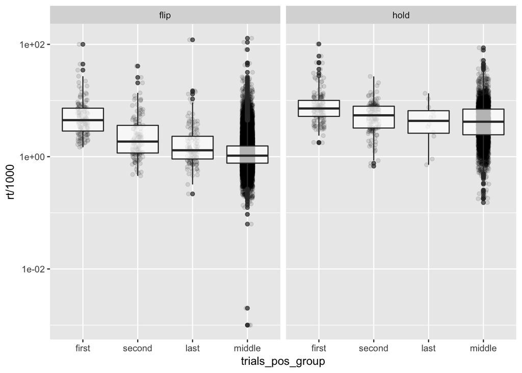

```r
d_long2 %>%
  ggplot(aes(x = trials_pos_group, y = rt/1000)) +
  geom_jitter(width = 0.1, alpha = .1) +
  scale_y_log10() +
  geom_boxplot(alpha = .7) +
  facet_wrap(~ type)
```

As can be seen, the first trials does not appear to be problematic, rather in the “middle” there appears to happen some “hitting-the-button” behavior, which is not indicative of high data quality.

## 3.3 Flag suspicious person

Let’s flag persons as “suspicous” if ONE of the follow conditions are met

1. RT < 300 ms in one trial (doesn’t matter which)
2. RT > 10 sec in one trial (as previous research is suspicious of time far above 3 seconds)

By this scheme, we will also capture persons with very few or with hella lot of trials.

```r
d_long3 <- d_long2 %>%
  ungroup() %>%
  mutate(is_suspicious_trial = case_when(
    rt < 300 ~ 1,
    rt > 10000 ~ 1,
    TRUE ~ 0
  ))
```

Let’s check the distribution of suspicious persons:

```r
d_suspects <- d_long3 %>%
  ungroup() %>%
  select(rt, is_suspicious_trial, id) %>%
  group_by(id) %>%
  summarise(is_suspicious_person = max(is_suspicious_trial))



d_suspects %>%
  count(is_suspicious_person)
```

```
## # A tibble: 2 x 2
##   is_suspicious_person     n
##                  <dbl> <int>
## 1                    0    26
## 2                    1   117
```

## 3.4 Add information about suspectibility to main data frames

### 3.4.1 long data frame

```r
d_long3 <- d_long3 %>%
  full_join(d_suspects) %>%
  select(id, is_suspicious_person, everything())
d_long3
```

```
## # A tibble: 20,139 x 70
##       id is_suspicious_p… type  id_trial trials_pos_group
##    <dbl>            <dbl> <chr>    <int> <fct>
##  1     1                1 flip         1 first
##  2     1                1 flip         2 second
##  3     1                1 flip         3 middle
##  4     1                1 flip         4 middle
##  5     1                1 flip         5 middle
##  6     1                1 flip         6 middle
##  7     1                1 flip         7 middle
##  8     1                1 flip         8 middle
##  9     1                1 flip         9 middle
## 10     1                1 flip        10 middle
## # … with 20,129 more rows, and 65 more variables: STARTED <dttm>,
## #   rt <dbl>, rt_md_hold <dbl>, rt_mean_hold <dbl>, rt_iqr_hold <dbl>,
## #   rt_sd_hold <dbl>, rt_md_flip <dbl>, rt_mean_flip <dbl>,
## #   rt_iqr_flip <dbl>, rt_sd_flip <dbl>, mindfulness_score <dbl>,
## #   mindfulness_training <dbl>, CASE <dbl>, SERIAL <lgl>, REF <lgl>,
## #   QUESTNNR <chr>, MODE <chr>, PE01_01 <dbl>, PE02 <dbl>, PE03 <dbl>,
## #   PE04 <dbl>, PE05 <dbl>, PE06 <dbl>, PE07_01 <chr>, PE08 <dbl>,
## #   PE08_06 <chr>, PE09 <dbl>, MA01_01 <dbl>, MA01_02 <dbl>,
## #   MA01_03 <dbl>, MA01_04 <dbl>, MA01_05 <dbl>, MA01_07 <dbl>,
## #   MA01_08 <dbl>, MA01_09 <dbl>, MA01_10 <dbl>, MA01_12 <dbl>,
## #   MA01_13 <dbl>, MA01_14 <dbl>, MA01_15 <dbl>, MA01_16 <dbl>,
## #   MA01_17 <dbl>, NW03_01 <chr>, NW04_01 <chr>, TIME001 <dbl>,
## #   TIME002 <dbl>, TIME003 <dbl>, TIME004 <dbl>, TIME005 <dbl>,
## #   TIME006 <dbl>, TIME007 <dbl>, TIME008 <dbl>, TIME_SUM <dbl>,
## #   MAILSENT <lgl>, LASTDATA <dttm>, FINISHED <dbl>, Q_VIEWER <dbl>,
## #   LASTPAGE <dbl>, MAXPAGE <dbl>, MISSING <dbl>, MISSREL <dbl>,
## #   TIME_RSI <dbl>, DEG_TIME <dbl>, mindlessness_score <dbl>,
## #   is_suspicious_trial <dbl>
```

## 3.5 Set suspicious RT to NA

One further way to deal with suspicious data is to set it to NA. Let’s try that.

```r
d_long4 <- d_long3 %>%
  ungroup() %>%
  mutate(rt_not_suspect = case_when(
    is_suspicious_trial != 0  ~ NA_real_,
    TRUE ~ rt
  )) %>%
  select(id, rt_not_suspect, everything())

d_long4
```

```
## # A tibble: 20,139 x 71
##       id rt_not_suspect is_suspicious_p… type  id_trial trials_pos_group
##    <dbl>          <dbl>            <dbl> <chr>    <int> <fct>
##  1     1           7050                1 flip         1 first
##  2     1           4857                1 flip         2 second
##  3     1            776                1 flip         3 middle
##  4     1           1185                1 flip         4 middle
##  5     1             NA                1 flip         5 middle
##  6     1             NA                1 flip         6 middle
##  7     1             NA                1 flip         7 middle
##  8     1             NA                1 flip         8 middle
##  9     1            387                1 flip         9 middle
## 10     1             NA                1 flip        10 middle
## # … with 20,129 more rows, and 65 more variables: STARTED <dttm>,
## #   rt <dbl>, rt_md_hold <dbl>, rt_mean_hold <dbl>, rt_iqr_hold <dbl>,
## #   rt_sd_hold <dbl>, rt_md_flip <dbl>, rt_mean_flip <dbl>,
## #   rt_iqr_flip <dbl>, rt_sd_flip <dbl>, mindfulness_score <dbl>,
## #   mindfulness_training <dbl>, CASE <dbl>, SERIAL <lgl>, REF <lgl>,
## #   QUESTNNR <chr>, MODE <chr>, PE01_01 <dbl>, PE02 <dbl>, PE03 <dbl>,
## #   PE04 <dbl>, PE05 <dbl>, PE06 <dbl>, PE07_01 <chr>, PE08 <dbl>,
## #   PE08_06 <chr>, PE09 <dbl>, MA01_01 <dbl>, MA01_02 <dbl>,
## #   MA01_03 <dbl>, MA01_04 <dbl>, MA01_05 <dbl>, MA01_07 <dbl>,
## #   MA01_08 <dbl>, MA01_09 <dbl>, MA01_10 <dbl>, MA01_12 <dbl>,
## #   MA01_13 <dbl>, MA01_14 <dbl>, MA01_15 <dbl>, MA01_16 <dbl>,
## #   MA01_17 <dbl>, NW03_01 <chr>, NW04_01 <chr>, TIME001 <dbl>,
## #   TIME002 <dbl>, TIME003 <dbl>, TIME004 <dbl>, TIME005 <dbl>,
## #   TIME006 <dbl>, TIME007 <dbl>, TIME008 <dbl>, TIME_SUM <dbl>,
## #   MAILSENT <lgl>, LASTDATA <dttm>, FINISHED <dbl>, Q_VIEWER <dbl>,
## #   LASTPAGE <dbl>, MAXPAGE <dbl>, MISSING <dbl>, MISSREL <dbl>,
## #   TIME_RSI <dbl>, DEG_TIME <dbl>, mindlessness_score <dbl>,
## #   is_suspicious_trial <dbl>
```

## 3.6 Add trials count summary to main person level data frame

By the way, let’s add the information on the number of trials (per person, per block) to the main person-level data frame.

```r
trials_count <- d_long2 %>%
  group_by(id, type) %>%
  summarise(trials_count = n()) %>%
  spread(key = type, value = trials_count) %>%
  rename(trials_count_flip = flip,
         trials_count_hold = hold)

trials_count
```

```
## # A tibble: 143 x 3
## # Groups:   id [143]
##       id trials_count_flip trials_count_hold
##    <dbl>             <int>             <int>
##  1     1                53                15
##  2     2               150                26
##  3     3               115                23
##  4     4               136                35
##  5     5                 3                 1
##  6     6               107                45
##  7     7               101                30
##  8     8                28                26
##  9     9               101                57
## 10    10                88                47
## # … with 133 more rows
```

### 3.6.1 Join to main l2 data frame (the short one, person level)

```r
d3 <- d2 %>%
  full_join(trials_count) %>%
  select(id, contains("trials_count"), everything())
d3
```

```
## # A tibble: 143 x 67
##       id trials_count_fl… trials_count_ho… rt_md_hold rt_mean_hold
##    <dbl>            <int>            <int>      <dbl>        <dbl>
##  1     1               53               15      8835        10047.
##  2     2              150               26      5690.        6756.
##  3     3              115               23      7787         7187.
##  4     4              136               35      5247         5106.
##  5     5                3                1      1792         1792
##  6     6              107               45      3119         3968.
##  7     7              101               30      3694.        5753.
##  8     8               28               26      4342.        6872.
##  9     9              101               57      2581         3119.
## 10    10               88               47      2814         3765.
## # … with 133 more rows, and 62 more variables: rt_iqr_hold <dbl>,
## #   rt_sd_hold <dbl>, rt_md_flip <dbl>, rt_mean_flip <dbl>,
## #   rt_iqr_flip <dbl>, rt_sd_flip <dbl>, mindfulness_score <dbl>,
## #   mindfulness_training <dbl>, mindfulness_sd <dbl>, STARTED <dttm>,
## #   CASE <dbl>, SERIAL <lgl>, REF <lgl>, QUESTNNR <chr>, MODE <chr>,
## #   PE01_01 <dbl>, PE02 <dbl>, PE03 <dbl>, PE04 <dbl>, PE05 <dbl>,
## #   PE06 <dbl>, PE07_01 <chr>, PE08 <dbl>, PE08_06 <chr>, PE09 <dbl>,
## #   MA01_01 <dbl>, MA01_02 <dbl>, MA01_03 <dbl>, MA01_04 <dbl>,
## #   MA01_05 <dbl>, MA01_07 <dbl>, MA01_08 <dbl>, MA01_09 <dbl>,
## #   MA01_10 <dbl>, MA01_12 <dbl>, MA01_13 <dbl>, MA01_14 <dbl>,
## #   MA01_15 <dbl>, MA01_16 <dbl>, MA01_17 <dbl>, NW03_01 <chr>,
## #   NW04_01 <chr>, TIME001 <dbl>, TIME002 <dbl>, TIME003 <dbl>,
## #   TIME004 <dbl>, TIME005 <dbl>, TIME006 <dbl>, TIME007 <dbl>,
## #   TIME008 <dbl>, TIME_SUM <dbl>, MAILSENT <lgl>, LASTDATA <dttm>,
## #   FINISHED <dbl>, Q_VIEWER <dbl>, LASTPAGE <dbl>, MAXPAGE <dbl>,
## #   MISSING <dbl>, MISSREL <dbl>, TIME_RSI <dbl>, DEG_TIME <dbl>,
## #   mindlessness_score <dbl>
```

### 3.6.2 Join to main l1 data frame (the long one, trials level)

```r
d_long5 <- d_long4 %>%
  full_join(trials_count) %>%
  select(id, contains("trials_count"), everything())
d_long5
```

```
## # A tibble: 20,139 x 73
##       id trials_count_fl… trials_count_ho… rt_not_suspect is_suspicious_p…
##    <dbl>            <int>            <int>          <dbl>            <dbl>
##  1     1               53               15           7050                1
##  2     1               53               15           4857                1
##  3     1               53               15            776                1
##  4     1               53               15           1185                1
##  5     1               53               15             NA                1
##  6     1               53               15             NA                1
##  7     1               53               15             NA                1
##  8     1               53               15             NA                1
##  9     1               53               15            387                1
## 10     1               53               15             NA                1
## # … with 20,129 more rows, and 68 more variables: type <chr>,
## #   id_trial <int>, trials_pos_group <fct>, STARTED <dttm>, rt <dbl>,
## #   rt_md_hold <dbl>, rt_mean_hold <dbl>, rt_iqr_hold <dbl>,
## #   rt_sd_hold <dbl>, rt_md_flip <dbl>, rt_mean_flip <dbl>,
## #   rt_iqr_flip <dbl>, rt_sd_flip <dbl>, mindfulness_score <dbl>,
## #   mindfulness_training <dbl>, CASE <dbl>, SERIAL <lgl>, REF <lgl>,
## #   QUESTNNR <chr>, MODE <chr>, PE01_01 <dbl>, PE02 <dbl>, PE03 <dbl>,
## #   PE04 <dbl>, PE05 <dbl>, PE06 <dbl>, PE07_01 <chr>, PE08 <dbl>,
## #   PE08_06 <chr>, PE09 <dbl>, MA01_01 <dbl>, MA01_02 <dbl>,
## #   MA01_03 <dbl>, MA01_04 <dbl>, MA01_05 <dbl>, MA01_07 <dbl>,
## #   MA01_08 <dbl>, MA01_09 <dbl>, MA01_10 <dbl>, MA01_12 <dbl>,
## #   MA01_13 <dbl>, MA01_14 <dbl>, MA01_15 <dbl>, MA01_16 <dbl>,
## #   MA01_17 <dbl>, NW03_01 <chr>, NW04_01 <chr>, TIME001 <dbl>,
## #   TIME002 <dbl>, TIME003 <dbl>, TIME004 <dbl>, TIME005 <dbl>,
## #   TIME006 <dbl>, TIME007 <dbl>, TIME008 <dbl>, TIME_SUM <dbl>,
## #   MAILSENT <lgl>, LASTDATA <dttm>, FINISHED <dbl>, Q_VIEWER <dbl>,
## #   LASTPAGE <dbl>, MAXPAGE <dbl>, MISSING <dbl>, MISSREL <dbl>,
## #   TIME_RSI <dbl>, DEG_TIME <dbl>, mindlessness_score <dbl>,
## #   is_suspicious_trial <dbl>
```

# 4 Save to disk

Define object name to be saved, so that the retrieved object in a further analysis will always have the same name independent of the index (eg., d_long4 or d_long6) of the final object.

```r
d_long_cleaned <- d_long5
d_short_cleaned <- d3
```

```
## Data files have NOT been saved to disk.
```